# RNA-seq Differential Analysis with R

Benjamin King, PhD | bking@mdibl.org | Kyle Shank | kshank@mdibl.org |

# Objective

# Step 0: Required Libraries

`DESeq2` is a package from [Bioconductor](https://www.bioconductor.org), an open source set of software tools in `R` for bioinformatics. To install:

```r
# If you have not installed Bioconductor, do so here!

# source("https://bioconductor.org/biocLite.R")
# biocLite()

# Once this is completed:
biocLite("DESeq2")
# You may then use library(DESeq2) for subsequent loads.
```

To see the vignette, or training materials, associated with the `DESeq2` package (highly recommended) use the following command:

```r
vignette("DESeq2")
```

# Step 1: Preparing Data

At this point, we should have three seperate datasets: `SRR647673_htseq.txt`, `SRR647674_htseq.txt`, and `SRR647675_htseq.txt`. Load these into your working environment in R, then examine one of the files with the `head()` function.

```r
# Note: You will need to change the relative path to wherever you have downloaded these files.

SRR647673 <- read.table("SRR647673_htseq.txt",head=FALSE)
SRR647674 <- read.table("SRR647674_htseq.txt",head=FALSE)
SRR647675 <- read.table("SRR647675_htseq.txt",head=FALSE)
head(SRR647673)
```

```
##        V1   V2
## 1  gene:1 2046
## 2 gene:10  153
## 3 gene:11   42
## 4 gene:12   78
## 5 gene:13   19
## 6 gene:14   67
```

As can be seen, `R` has automatically assigned a name to the two columns: *V1*, the identified gene, and *V2*, the count of reads that have been assigned to that read. Of importance is the fact that the count data here has not been normalized. Why? For `DESeq2`’s statistical model to hold, raw counts must be used as these allow for assessing the measurement precision correctly. It is important to never provide counts that were pre-normalized for sequencing depth/library size to `DESeq2`.

We now need to merge these datasets to obtain a matrix of counts. Merges (or, more abstractly, joins) can be extraordinarily complicated tasks in different computational environment - `R` is no exception. To begin, it is always good practice to ensure that you have a common column (a “key”) that is found across all datasets. Here, it is *V1* (which we will rename “Gene” in the matrix). To ensure that these are indeed the same, we can use a logic statement. We will check to see if all elements of the `V1` column are the same across all three datasets.

```r
all(SRR647673[,1]==SRR647674[,1]) && all(SRR647673[,1]==SRR647675[,1]) && all(SRR647674[,1]==SRR647675[,1])
```

```
## [1] TRUE
```

Great! We can perform a merge. There are ([literally](https://www.google.com/search?client=safari&rls=en&q=how+many+ways+to+merge+in+r&ie=UTF-8&oe=UTF-8#safe=off&q=how+to+merge+in+r)) a million ways to perform a merge in `R`. As we know that our key column is identical across the three datasets, our circumstances are trivial and can actually be performed easily via creating a new *data.frame* object.

```r
countData<-data.frame(row.names =SRR647673[,1],SRR647673=SRR647673[,2],SRR647674=SRR647674[,2],SRR647675=SRR647675[,2])
head(countData)
```

```
##         SRR647673 SRR647674 SRR647675
## gene:1       2046      5563        17
## gene:10       153     84585        24
## gene:11        42     23166       340
## gene:12        78     37991        34
## gene:13        19      9037         0
## gene:14        67     34953        66
```

```r
tail(countData)
```

```
##         SRR647673 SRR647674 SRR647675
## gene:76       229       525       139
## gene:77       329       436        79
## gene:78      1753      3023       130
## gene:8         90     18852       149
## gene:80         0         0         0
## gene:9        318     77199        69
```

```r
## Note that all samples contain a 0 for "gene:80", so remove it
countData<-countData[-77,]
tail(countData)
```

```
##         SRR647673 SRR647674 SRR647675
## gene:75       146       317       164
## gene:76       229       525       139
## gene:77       329       436        79
## gene:78      1753      3023       130
## gene:8         90     18852       149
## gene:9        318     77199        69
```

The class used by the `DESeq2` package to store the read counts is a *DESeqDataSet* object, which extends the *Ranged-SummarizedExperiment* class of the `SummarizedExperiment` package. This facilitates preparation steps and also downstream exploration of results. It is highly recommended to be come familiar with these object types (use `vignette(SummarizedExperiment)`), as they are used widely throughout the Bioconductor landscape in `R`.

In practical terms, this means we need to create a dataset of meta data, and then merge both our *countData* and *metaData* into one *DESeqDataSet* object.

```r
(metaData<-data.frame(row.names = colnames(countData), condition = c("30MinPI","2point5HoursPI","Lysogen")))
```

```
##                condition
## SRR647673        30MinPI
## SRR647674 2point5HoursPI
## SRR647675        Lysogen
```

We can now create our *DESeqDataSet* object:

```r
deseq.dat<- DESeqDataSetFromMatrix(countData = countData,
                                   colData = metaData,
                                   design = ~ condition)
deseq.dat
```

```
## class: DESeqDataSet
## dim: 77 3
## metadata(1): version
## assays(1): counts
## rownames(77): gene:1 gene:10 ... gene:8 gene:9
## rowData names(0):
## colnames(3): SRR647673 SRR647674 SRR647675
## colData names(1): condition
```

```r
head(assay(deseq.dat))
```

```
##         SRR647673 SRR647674 SRR647675
## gene:1       2046      5563        17
## gene:10       153     84585        24
## gene:11        42     23166       340
## gene:12        78     37991        34
## gene:13        19      9037         0
## gene:14        67     34953        66
```

As with `R`: there’s more than one way to do things! If you’d like to short-cut the above manual steps, you can utilize the following commands below. Note that these commands will only work if your working directory is where the *.txt* files are located.

```r
sampleFiles<-grep("SRR",list.files(getwd()),value=TRUE)
sampleCondition<-c("30MinPI","2point5HoursPI","Lysogen")
sampleTable<-data.frame(sampleName=gsub("_htseq.txt","",sampleFiles),
                        fileName = sampleFiles,
                        condition=sampleCondition)
deseq.dat2<-DESeqDataSetFromHTSeqCount(sampleTable=sampleTable,
                                     directory = getwd(),
                                     design= ~ condition)
deseq.dat2
```

```
## class: DESeqDataSet
## dim: 78 3
## metadata(1): version
## assays(1): counts
## rownames(78): gene:1 gene:10 ... gene:80 gene:9
## rowData names(0):
## colnames(3): SRR647673 SRR647674 SRR647675
## colData names(1): condition
```

```r
head(assay(deseq.dat2))
```

```
##         SRR647673 SRR647674 SRR647675
## gene:1       2046      5563        17
## gene:10       153     84585        24
## gene:11        42     23166       340
## gene:12        78     37991        34
## gene:13        19      9037         0
## gene:14        67     34953        66
```

# Step 2: Using DESeq2

The standard differential expression analysis steps are wrapped into a single function, `DESeq`. Results tables are generated using the function results, which extracts a results table with $\log_2$ fold changes, *p* values and adjusted *p* values. With no arguments to results, the results will be for the last variable in the design formula, and if this is a factor, the comparison will be the last level of this variable over the first level. Details about the comparison are printed to the console. The text, condition treated vs untreated, tells you that the estimates are of the logarithmic fold change log2(treated/untreated).

```r
dds <- DESeq(deseq.dat,quiet=TRUE)
```

```
## -- note: fitType='parametric', but the dispersion trend was not well captured by the
##    function: y = a/x + b, and a local regression fit was automatically substituted.
##    specify fitType='local' or 'mean' to avoid this message next time.
```

```r
head(results(dds))
```

```
## log2 fold change (MAP): condition Lysogen vs 2point5HoursPI
## Wald test p-value: condition Lysogen vs 2point5HoursPI
## DataFrame with 6 rows and 6 columns
##          baseMean log2FoldChange     lfcSE      stat    pvalue      padj
##         <numeric>      <numeric> <numeric> <numeric> <numeric> <numeric>
## gene:1   884.0707     -2.3093350  1.855291 -1.244729 0.2132313 0.4906545
## gene:10 5568.1980     -4.5829000  2.465534 -1.858786 0.0630575 0.4097192
## gene:11 2620.0824     -0.3520614  2.210830 -0.159244 0.8734766 0.9601247
## gene:12 2579.3242     -3.6052714  2.284374 -1.578231 0.1145125 0.4640768
## gene:13  587.0899     -3.5018195  2.741749 -1.277221 0.2015242 0.4906545
## gene:14 2485.9970     -2.7782088  2.245812 -1.237062 0.2160641 0.4906545
```

```r
summary(results(dds))
```

```
##
## out of 77 with nonzero total read count
## adjusted p-value < 0.1
## LFC > 0 (up)     : 0, 0%
## LFC < 0 (down)   : 0, 0%
## outliers [1]     : 0, 0%
## low counts [2]   : 0, 0%
## (mean count < 39)
## [1] see 'cooksCutoff' argument of ?results
## [2] see 'independentFiltering' argument of ?results
```

As you can see - we have found no differentially expressed genes due to our lack of statistical pwoer. For an interesting history on this topic, a look at [this](http://seqanswers.com/forums/showthread.php?t=31036) aging thread might be of value.

There is, however, a workaround for our particular case! Though we will not be able to assign *p*-values to any of our differentially expressed genes, we still have the capability of performing $\log_2$ transformations to check for absolute (and not statistical) differences in expression.

```r
rld <- rlogTransformation(dds)
```

```
## -- note: fitType='parametric', but the dispersion trend was not well captured by the
##    function: y = a/x + b, and a local regression fit was automatically substituted.
##    specify fitType='local' or 'mean' to avoid this message next time.
```

```r
res <- data.frame(
   assay(rld))
res$avgLogExpr <- ( res[,1]+res[,2]+res[,3] ) / 3
res$LogFC.73.74 <- res$SRR647673 - res$SRR647674
res$LogFC.73.75 <- res$SRR647673 - res$SRR647675
res$LogFC.74.75 <- res$SRR647674 - res$SRR647675
head(res)
```

```
##         SRR647673 SRR647674 SRR647675 avgLogExpr LogFC.73.74 LogFC.73.75
## gene:1  10.258202  9.937125  7.817793   9.337707   0.3210776   2.4404091
## gene:10  7.949711 13.032059  8.587195   9.856322  -5.0823483  -0.6374833
## gene:11  6.474716 11.676800 11.330747   9.827421  -5.2020838  -4.8560311
## gene:12  6.709448 12.166878  8.567606   9.147977  -5.4574298  -1.8581581
## gene:13  4.084918 10.061743  2.728522   5.625061  -5.9768253   1.3563966
## gene:14  6.640638 12.104616  9.349334   9.364863  -5.4639789  -2.7086966
##         LogFC.74.75
## gene:1    2.1193315
## gene:10   4.4448649
## gene:11   0.3460527
## gene:12   3.5992717
## gene:13   7.3332219
## gene:14   2.7552823
```

It’s important to understand what the `rlogTransformation` function is doing. This function transforms the count data to the $\log_2$ scale in a way which minimizes differences between samples for rows with small counts, and which normalizes with respect to library size. It’s called the regularized $\log_2$ transformation, and it’s a method for variance stabilization. [This paper](http://genomebiology.biomedcentral.com/articles/10.1186/s13059-014-0550-8) offers some pretty good clarification for why this is important.

Here’s a good example of why the `rlog` transformation is appropriate:

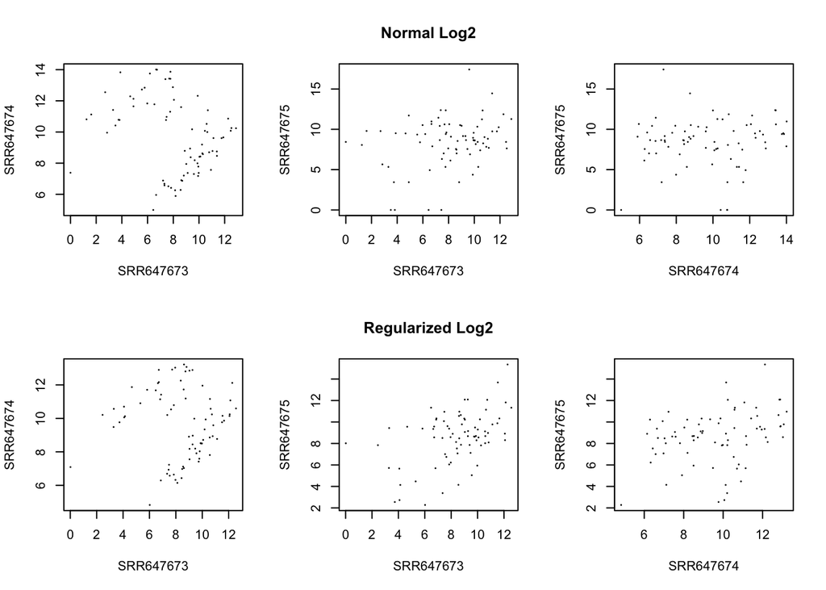

```r
par( mfrow = c( 2, 3 ) )
ddplot <- estimateSizeFactors(dds)
plot(log2(counts(dds, normalized=TRUE)[,1:2] + 1),
     pch=16, cex=0.3) +
plot(log2(counts(dds, normalized=TRUE)[,c(1,3)] + 1),
     pch=16, cex=0.3, main = "Normal Log2") +
plot(log2(counts(dds, normalized=TRUE)[,2:3] + 1),
     pch=16, cex=0.3) +
plot(assay(rld)[,1:2],
     pch=16, cex=0.3) +
plot(assay(rld)[,c(1,3)],
     pch=16, cex=0.3, main="Regularized Log2") +
plot(assay(rld)[,2:3],
     pch=16, cex=0.3)
```

We can see how genes with low counts (bottom left-hand corner of the first two plots on the top row) seem to be excessively variable on the ordinary logarithmic scale, while the rlog transform compresses differences for the low count genes for which the data provide little information about differential expression.

# Step 3: Exploratory Data Analysis

Exploratory data analysis (EDA) is an incredibly importat part of bioinformatics (and data analysis in general). There are many great resources on this topic available (like this, [this](http://www.stat.cmu.edu/~hseltman/309/Book/chapter4.pdf), and this). Below are some of the more standardized tasks for differential analysis.

## Heat Map

A useful first step in an RNA-seq analysis is often to assess overall similarity between samples: Which samples are similar to each other, which are different? Does this fit to the expectation from the experiment’s design? A good way to assess this is to find the [Euclidian](https://en.wikipedia.org/wiki/Euclidean_distance) (or sometimes [Poisson](https://arxiv.org/pdf/1202.6201.pdf)) distance and plot it with a heatmap.

To do this, we’ll need a few extra libraries:

```r
library("pheatmap")
library("RColorBrewer")
```

We’ll use the `dist` function to get the Euclidian distance on a transposed array.

```r
sampleDists <- dist( t( assay(rld) ) )
sampleDists
```

```
##           SRR647673 SRR647674
## SRR647674  30.44802
## SRR647675  22.36172  25.18924
```

Then we simply convert to a matrix and plot.

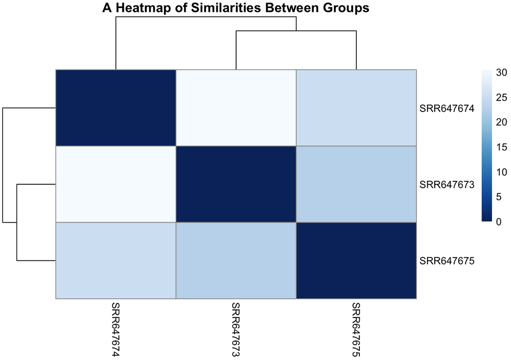

```r
sampleDistMatrix <- as.matrix( sampleDists )
# This is just to make the heatmap more attractive
colors <- colorRampPalette( rev(brewer.pal(9, "Blues")) )(255)
pheatmap(sampleDistMatrix,
         clustering_distance_rows=sampleDists,
         clustering_distance_cols=sampleDists,
         col=colors,
         main = "A Heatmap of Similarities Between Groups")
```

## MA Plot

The MA plot allows you to look at the relationship between intensity and difference between two different sets of data. More specifically, an MA-plot is a plot of log-intensity ratios (M-values) versus log-intensity averages (A-values).

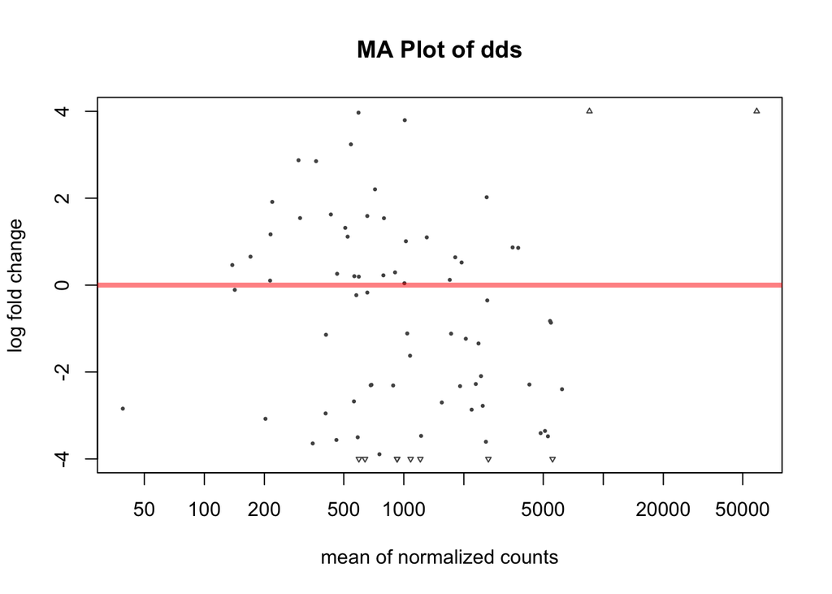

```r
plotMA(results(dds),main = "MA Plot of dds",ylim=c(-4,4))
```

The default behavior of the `plotMA` function would be to highlight differentially expressed genes (as determined by the adjusted p-value). We can again confirm that we have none via the following method:

```r
table(results(dds)[,"padj"]<0.1)
```

```
##
## FALSE
##    77
```

To see the standard (or expected) output of the `plotMA` function, we can use the *airway* dataset.

```r
library("airway")
data("airway")
se <- airway
dat<-DESeqDataSet(se, design = ~ cell + dex)
ex<-DESeq(dat)
```

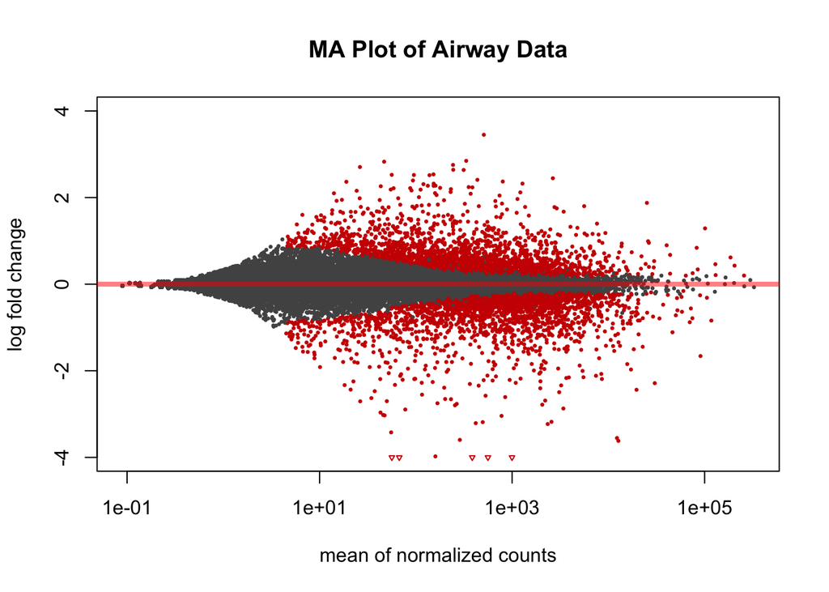

```r
exrl<-rlog(ex)
rs<-results(ex)
plotMA(rs,main="MA Plot of Airway Data",ylim=c(-4,4))
```

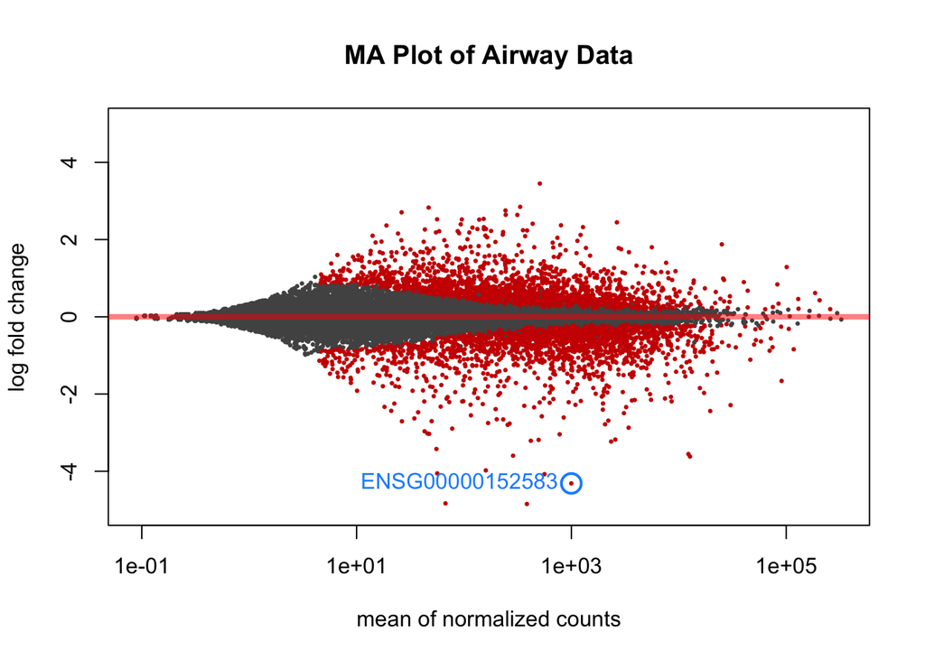

```r
plotMA(rs, main="MA Plot of Airway Data",ylim=c(-5,5))
topGene <- rownames(rs)[which.min(rs$padj)]
with(rs[topGene, ], {
  points(baseMean, log2FoldChange, col="dodgerblue", cex=2, lwd=2)
  text(baseMean, log2FoldChange, topGene, pos=2, col="dodgerblue")
})
```

## PCA Plot

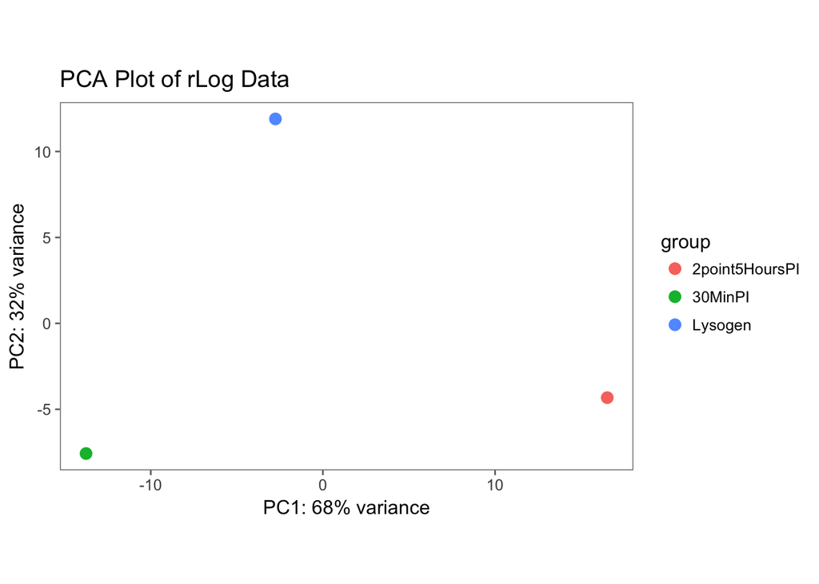

```r
require(ggplot2,ggthemes)
plotPCA(rld) + ggtitle("PCA Plot of rLog Data") + theme_few()
```

With our **airway** dataset:

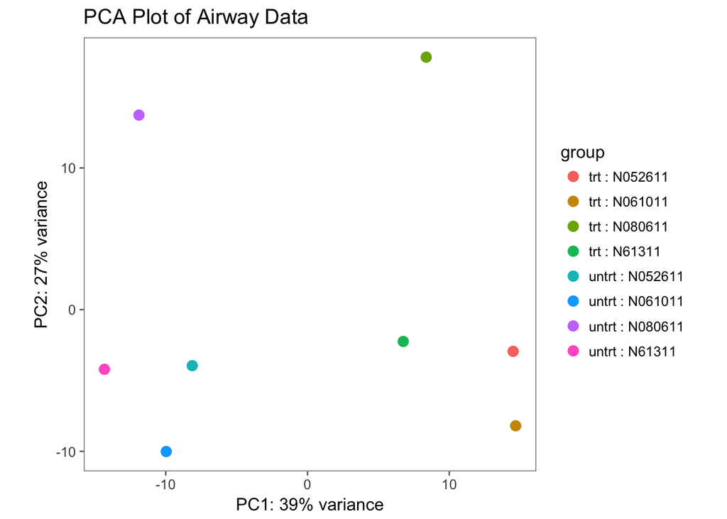

```r
plotPCA(exrl,intgroup=c("dex","cell"))+ ggtitle("PCA Plot of Airway Data") + theme_few()
```

# Step 4: Annotation

An important step taken towards the end of an analysis pipeline is annotating your results. What we’ll go through now is retrieving an annotation file and merging it with our table to produce an annotated list of genes. We’ll then write that file out to our working directory.

First, download the annotation file and save it in your working directory. You can find that file [here](http://applbio.mdibl.org/giles_annotation.txt). Now, read that file into `R`.

```r
annotation <- read.table(file="giles_annotation.txt",sep="\t",head=T,stringsAsFactors=FALSE)
head(annotation)
```

```
##    Symbol Start  End Strand Product            Note      ProteinID
## 1 Giles_1    14  571      +     gp1                 YP_001552330.1
## 2 Giles_2   630  800      -     gp2                 YP_001552331.1
## 3 Giles_3   930 1553      -     gp3                 YP_001552332.1
## 4 Giles_4  1617 1826      -     gp4                 YP_001552333.1
## 5 Giles_5  1855 3489      +     gp5       terminase YP_001552334.1
## 6 Giles_6  3506 4915      +     gp6 probably portal YP_001552335.1
##   NCBIGeneID
## 1    5758937
## 2    5758932
## 3    5758939
## 4    5758936
## 5    5758934
## 6    5758935
```

As you can see, the annotation file contains a lot of useful information. What we need to do is now combine it with the *res* file that we created in a previous step. Let’s examine that file again.

```r
head(res)
```

```
##         SRR647673 SRR647674 SRR647675 avgLogExpr LogFC.73.74 LogFC.73.75
## gene:1  10.258202  9.937125  7.817793   9.337707   0.3210776   2.4404091
## gene:10  7.949711 13.032059  8.587195   9.856322  -5.0823483  -0.6374833
## gene:11  6.474716 11.676800 11.330747   9.827421  -5.2020838  -4.8560311
## gene:12  6.709448 12.166878  8.567606   9.147977  -5.4574298  -1.8581581
## gene:13  4.084918 10.061743  2.728522   5.625061  -5.9768253   1.3563966
## gene:14  6.640638 12.104616  9.349334   9.364863  -5.4639789  -2.7086966
##         LogFC.74.75
## gene:1    2.1193315
## gene:10   4.4448649
## gene:11   0.3460527
## gene:12   3.5992717
## gene:13   7.3332219
## gene:14   2.7552823
```

What we need to do is find a “key” to merge our datasets by. We do not have a unified key that stands out, so we’ll need to make one. Did you notice something interesting about the rownames of *res* and the first column of *annotation*?

```r
rownames(res)
```

```
##  [1] "gene:1"  "gene:10" "gene:11" "gene:12" "gene:13" "gene:14" "gene:15"
##  [8] "gene:16" "gene:17" "gene:18" "gene:19" "gene:2"  "gene:20" "gene:21"
## [15] "gene:22" "gene:23" "gene:24" "gene:25" "gene:26" "gene:27" "gene:28"
## [22] "gene:29" "gene:3"  "gene:30" "gene:31" "gene:32" "gene:33" "gene:34"
## [29] "gene:35" "gene:36" "gene:37" "gene:38" "gene:39" "gene:4"  "gene:40"
## [36] "gene:41" "gene:42" "gene:43" "gene:44" "gene:45" "gene:46" "gene:47"
## [43] "gene:49" "gene:5"  "gene:50" "gene:51" "gene:52" "gene:53" "gene:54"
## [50] "gene:55" "gene:56" "gene:57" "gene:58" "gene:59" "gene:6"  "gene:60"
## [57] "gene:61" "gene:62" "gene:63" "gene:64" "gene:65" "gene:66" "gene:67"
## [64] "gene:68" "gene:69" "gene:7"  "gene:70" "gene:71" "gene:72" "gene:73"
## [71] "gene:74" "gene:75" "gene:76" "gene:77" "gene:78" "gene:8"  "gene:9"
```

```r
annotation$Symbol
```

```
##  [1] "Giles_1"  "Giles_2"  "Giles_3"  "Giles_4"  "Giles_5"  "Giles_6"
##  [7] "Giles_7"  "Giles_8"  "Giles_9"  "Giles_10" "Giles_11" "Giles_12"
## [13] "Giles_13" "Giles_14" "Giles_15" "Giles_16" "Giles_17" "Giles_18"
## [19] "Giles_19" "Giles_20" "Giles_21" "Giles_22" "Giles_23" "Giles_24"
## [25] "Giles_25" "Giles_26" "Giles_27" "Giles_28" "Giles_29" "Giles_30"
## [31] "Giles_31" "Giles_32" "Giles_33" "Giles_34" "Giles_35" "Giles_36"
## [37] "Giles_37" "Giles_38" "Giles_39" "Giles_40" "Giles_41" "Giles_42"
## [43] "Giles_43" "Giles_44" "Giles_45" "Giles_46" "Giles_47" "Giles_49"
## [49] "Giles_50" "Giles_51" "Giles_52" "Giles_53" "Giles_54" "Giles_55"
## [55] "Giles_56" "Giles_57" "Giles_58" "Giles_59" "Giles_60" "Giles_61"
## [61] "Giles_62" "Giles_63" "Giles_64" "Giles_65" "Giles_66" "Giles_67"
## [67] "Giles_68" "Giles_69" "Giles_70" "Giles_71" "Giles_72" "Giles_73"
## [73] "Giles_74" "Giles_75" "Giles_76" "Giles_77" "Giles_78"
```

In order to “build” a key, we’ll need to do some string manipulation. First, we’ll need to make a column vector in the *res* dataframe that contains the “gene:##” string, as leaving it as a rowname won’t allow us to perform our merge.

```r
res$Gene<-rownames(res)
head(res)
```

```
##         SRR647673 SRR647674 SRR647675 avgLogExpr LogFC.73.74 LogFC.73.75
## gene:1  10.258202  9.937125  7.817793   9.337707   0.3210776   2.4404091
## gene:10  7.949711 13.032059  8.587195   9.856322  -5.0823483  -0.6374833
## gene:11  6.474716 11.676800 11.330747   9.827421  -5.2020838  -4.8560311
## gene:12  6.709448 12.166878  8.567606   9.147977  -5.4574298  -1.8581581
## gene:13  4.084918 10.061743  2.728522   5.625061  -5.9768253   1.3563966
## gene:14  6.640638 12.104616  9.349334   9.364863  -5.4639789  -2.7086966
##         LogFC.74.75    Gene
## gene:1    2.1193315  gene:1
## gene:10   4.4448649 gene:10
## gene:11   0.3460527 gene:11
## gene:12   3.5992717 gene:12
## gene:13   7.3332219 gene:13
## gene:14   2.7552823 gene:14
```

We’ll perform our string manipulation on the *annotation* data. What we need to do is:

- Seperate the string that we want (“Symbol”) into useful components
- Rename one part of that component so that it matches the correct element of the “Gene” vector in *res*.

```r
## Look at the annotation Gene Symbols
annotation$Symbol
```

```
##  [1] "Giles_1"  "Giles_2"  "Giles_3"  "Giles_4"  "Giles_5"  "Giles_6"
##  [7] "Giles_7"  "Giles_8"  "Giles_9"  "Giles_10" "Giles_11" "Giles_12"
## [13] "Giles_13" "Giles_14" "Giles_15" "Giles_16" "Giles_17" "Giles_18"
## [19] "Giles_19" "Giles_20" "Giles_21" "Giles_22" "Giles_23" "Giles_24"
## [25] "Giles_25" "Giles_26" "Giles_27" "Giles_28" "Giles_29" "Giles_30"
## [31] "Giles_31" "Giles_32" "Giles_33" "Giles_34" "Giles_35" "Giles_36"
## [37] "Giles_37" "Giles_38" "Giles_39" "Giles_40" "Giles_41" "Giles_42"
## [43] "Giles_43" "Giles_44" "Giles_45" "Giles_46" "Giles_47" "Giles_49"
## [49] "Giles_50" "Giles_51" "Giles_52" "Giles_53" "Giles_54" "Giles_55"
## [55] "Giles_56" "Giles_57" "Giles_58" "Giles_59" "Giles_60" "Giles_61"
## [61] "Giles_62" "Giles_63" "Giles_64" "Giles_65" "Giles_66" "Giles_67"
## [67] "Giles_68" "Giles_69" "Giles_70" "Giles_71" "Giles_72" "Giles_73"
## [73] "Giles_74" "Giles_75" "Giles_76" "Giles_77" "Giles_78"
```

```r
## Split the string at the "_" character to isolate the number
split <- strsplit(as.character(annotation$Symbol),'_')
## Turn this list of split strings into a dataframe
split<- data.frame(do.call(rbind, split))
## Append "gene:" to the front of the second column
split[,2] <- paste("gene:",split[,2],sep="")
## Append the second column back to the annotation data frame
annotation$Key <- split[,2]
head(annotation)
```

```
##    Symbol Start  End Strand Product            Note      ProteinID
## 1 Giles_1    14  571      +     gp1                 YP_001552330.1
## 2 Giles_2   630  800      -     gp2                 YP_001552331.1
## 3 Giles_3   930 1553      -     gp3                 YP_001552332.1
## 4 Giles_4  1617 1826      -     gp4                 YP_001552333.1
## 5 Giles_5  1855 3489      +     gp5       terminase YP_001552334.1
## 6 Giles_6  3506 4915      +     gp6 probably portal YP_001552335.1
##   NCBIGeneID    Key
## 1    5758937 gene:1
## 2    5758932 gene:2
## 3    5758939 gene:3
## 4    5758936 gene:4
## 5    5758934 gene:5
## 6    5758935 gene:6
```

We now have our key!

**Important Note**: The only reason we could “append” the above column is that we knew that the columns were already ordered and we had done nothing to change that order. In many situations, you may need to “merge” the data in the fashion that we will do so below.

Now that we have our key, we can perform a merge.

```r
anno.df<-merge(res,annotation,by.x="Gene",by.y="Key",all=T)
head(anno.df)
```

```
##      Gene SRR647673 SRR647674 SRR647675 avgLogExpr LogFC.73.74 LogFC.73.75
## 1  gene:1 10.258202  9.937125  7.817793   9.337707   0.3210776   2.4404091
## 2 gene:10  7.949711 13.032059  8.587195   9.856322  -5.0823483  -0.6374833
## 3 gene:11  6.474716 11.676800 11.330747   9.827421  -5.2020838  -4.8560311
## 4 gene:12  6.709448 12.166878  8.567606   9.147977  -5.4574298  -1.8581581
## 5 gene:13  4.084918 10.061743  2.728522   5.625061  -5.9768253   1.3563966
## 6 gene:14  6.640638 12.104616  9.349334   9.364863  -5.4639789  -2.7086966
##   LogFC.74.75   Symbol Start  End Strand Product           Note
## 1   2.1193315  Giles_1    14  571      +     gp1
## 2   4.4448649 Giles_10  7539 7979      +    gp10 virion protein
## 3   0.3460527 Giles_11  7983 8435      +    gp11
## 4   3.5992717 Giles_12  8435 9118      +    gp12 virion protein
## 5   7.3332219 Giles_13  9121 9528      +    gp13
## 6   2.7552823 Giles_14  9521 9922      +    gp14
##        ProteinID NCBIGeneID
## 1 YP_001552330.1    5758937
## 2 YP_001552339.1    5758944
## 3 YP_001552340.1    5758941
## 4 YP_001552341.1    5758950
## 5 YP_001552342.1    5758956
## 6 YP_001552343.1    5758940
```

Voila! You now have a merged data.frame with annotation information. You can write this information out to your working directory with the following command:

```r
write.csv(anno.df,file="AnnotatedGeneList.csv",row.names = FALSE)
```